# Industry News

Vol. 74

J.H AHN

2022-07-14

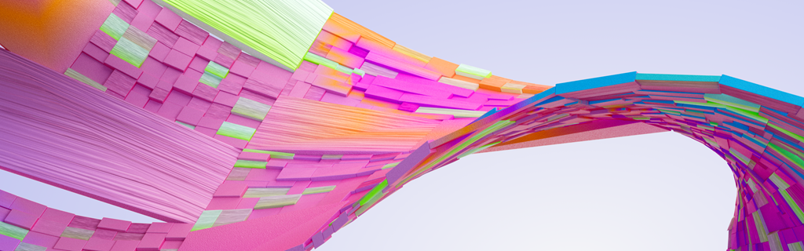

## 잡설

정신줄을 놓고 살고 있습니다.

대단한 일을 하는 것도 아닌데 뭔가 어수선해져서 정신을 못 차리고 있습니다.

적응할 때까지는 주말에 이걸 써서 보내야 하나 하는 고민도 하고 있는데… 일단 끝까지 한 번 해보겠습니다.

### 하나 - 제임스 웹, 첫번째 사진

21년 크리스마스에 올려보낸 제임스 웹이 이제 자리를 잡고 우주의 신비를 보내고 있습니다.

그저 경이로울 따름입니다.

1190광년 떨어진 별에 물이 있는 대기가 있다는 것을 알 수 있다는 것이 신기함을 넘어서 경외감마저 불러옵니다.

[James Webb Space Telescope](https://www.nasa.gov/webbfirstimages)

한 때 밤하늘을 참 좋아했다가 시들해졌는데, 제임스 웹의 사진을 보면서 뭔가 해보고 싶다는 생각이 들고 있습니다.

[figure not shown]

### 둘 - 고유가 시대, 독일인들은 신났다… 9유로 티켓의 놀라운 효과

고유가를 대처하는 가장 현명한 방법이 아닐까 합니다.

에너지 관련 언론들의 기사를 도배하더니 한국에서도 이제 이야기가 되기 시작하고 있습니다.

처음에 별거 아닌데 왠 호들갑이지? 라고 생각했는데 파장이 장난이 아닙니다.

어떨때 유럽인들이 참 어리석어 보이는데, 이런 정책 입안, 결정 과정을 보면 참 현명하다는 생각이 들기도 합니다.

[기사원문](http://www.ohmynews.com/NWS_Web/Series/series_premium_pg.aspx?CNTN_CD=A0002848731)

[figure not shown]

## 새로운 소식들

### Pope: Nations must work together to adapt to climate change

교황청 과학아카데미는 7월 13일부터 14일까지 바티칸의 카지노 피오 IV에서 “기후 스트레스 하에서 인간과 생태계의 회복력”이라는 주제에 초점을 맞춘 이틀간 회의를 주최

[기사링크](https://www.vaticannews.va/en/pope/news/2022-07/pope-francis-climate-change-resilience-ecosystems-biodiversity.html)

프란치스코 교황은 “생태학적 개종”에 대한 그의 거듭된 요청을 언급하면서, 이 과정은 모든 사람이 하느님의 창조에 감사하고, 서로 친교를 이루며, 환경 문제를 다루기 위해 함께 노력해야 한다고 언급

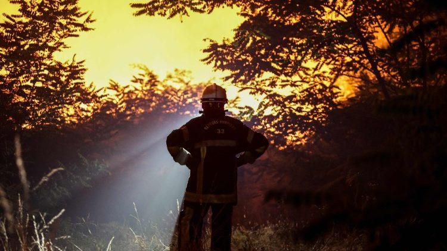

종교지도자까지 나서서 기후 변화를 경고하고 협력해야 한다고 말하는 세상이 도래했습니다.

안타깝게도 우리나라에서는 기후변화에 대한 인식이 너무 낮고 경각심이 없는 것 같습니다.

### This two-bladed offshore wind turbine can withstand hurricanes

[기사링크](https://electrek.co/2022/07/12/this-two-bladed-offshore-wind-turbine-can-withstand-hurricanes/)

콜로라도 볼더 대학교, 버지니아 대학교, 댈러스 텍사스 대학교, 콜로라도 광산 학교, 국립 재생 에너지 연구소(NREL)의 연구원들이 허리케인에도 견딜 수 있는 날개 2개인 풍력터빈을 개발

[figure not shown]

연구팀은 SUMR-D(Segmented Ultralight Morphing Rotor 시연기)로 알려진 53.38kW 터빈제작.

터빈은 2개의 가볍고 유연한 블레이드와 다운윈드 로터로 구성.

Boulder 남쪽의 NREL Flatirons 캠퍼스에서 4년 간의 연구에서 테스트 수행.

## 전력시장

### Wordcloud for Enerbility

[interactive chart not shown]

### 전력계통

<변동내역>

- 중앙급전발전기 : 변동사항 없음
- 비중앙급전발전기 : 북내지내2호 태양광발전소 신설 등[+27.0MW]

**best regards,**  
**J.H**

**Industry News?**  
매주 전력산업의 새로운 소식과 산업계 동향을 공유하는 뉴스레터입니다.  
Feedback은 언제라도 환영합니다.  
📫 junho.ahn@doosan.com

**END**